# Final Report

Sere Williams, Heather Deel, Sunny Liu, Khum Thapa-Magar

12/13/2019

```r
knitr::opts_chunk$set(echo = FALSE, message = FALSE, warning = FALSE, error = FALSE)
```

## Research questions:

Our research question aims to ask which categories appear most often in the 35 seasons that Jeopardy has run and if the top 5 categories have changed over time. Next we look at the most common categories that certain gods appear in, with some more in depth analysis of Zeus and Athena within these categories.

## Our two questions are:

Question 1: What are the top 5 categories in all seasons, and how often do these occur per year?

Question 2: What are the top 5 categories that different kinds of gods (Greek, Norse, Hindu) are mentioned either in the question or answer? How often are the popular Greek gods, Zeus and Athena, mentioned over time and within each of these categories?

## To begin we need to load libraries, load the data, and clean the data.

## Read in and clean the data

We read in the data and clean it by separating the air date into three columns, removing comments and notes, changing text to all lower case letters and removing data from 2019 as the season is only partially complete.

## A data table of the top 50 categories over all seasons

|  | category | count |
| --- | --- | --- |
| 1 | science | 845 |
| 2 | literature | 804 |
| 3 | american history | 762 |
| 4 | history | 709 |
| 5 | sports | 701 |
| 6 | potpourri | 684 |
| 7 | word origins | 667 |
| 8 | before &amp; after | 661 |
| 9 | world history | 640 |
| 10 | world geography | 629 |

[output cut: 40 more lines]

## What is the proportion of questions from the top 5 categories by year?

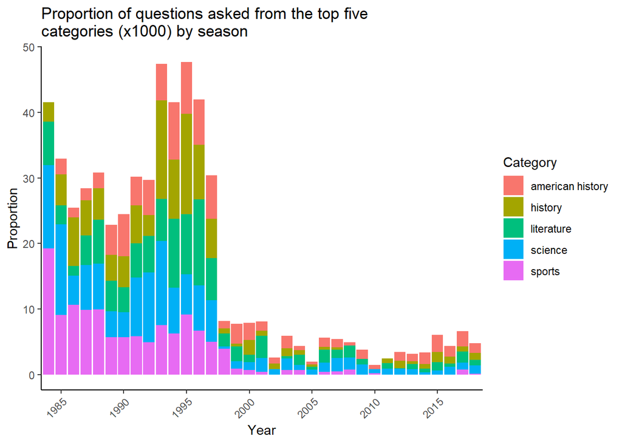

As the plot shows, there is a change in the proportion of questions asked from the top five categories after 1997.

## Did the top 5 most commonly used categories change after 1997? Let’s look at a data table of the top 50 categories from 1998 to 2018.

|  | category | count |
| --- | --- | --- |
| 1 | before &amp; after | 646 |
| 2 | word origins | 380 |
| 3 | american history | 376 |
| 4 | potpourri | 344 |
| 5 | literature | 301 |
| 6 | science | 292 |
| 7 | rhyme time | 288 |
| 8 | stupid answers | 286 |
| 9 | world capitals | 276 |
| 10 | bodies of water | 275 |

[output cut: 40 more lines]

As the table shows, two of the top five categories from all seasons are also in the top five categories from 1998-2018: american history and literature. Science appears at #6, however history and sports are not even in the top 10. From 1998-2018, history is the 31st most asked category and sports is 81st (not on the top 50 list).  
Before & after, word origins, and potpourri are now in the top five. Note that these three categories were in the top 10 categories of all seasons.

## Create dataframe filtered by different kinds of gods, all merged into one dataframe

## Group by category, filter by top 5 categories

After grouping by category and taking the count of each, the dataframe with all gods was filtered down to just to top 5 categories - “Authors”, “Books & Authors”, “Literature”, “Mythology”, and “English Literature”.

## Create a god_name column that specifies whether Zeus or Athena was mentioned in the question or answer

## Fill by Zeus or Athena to look at their prevalences over time

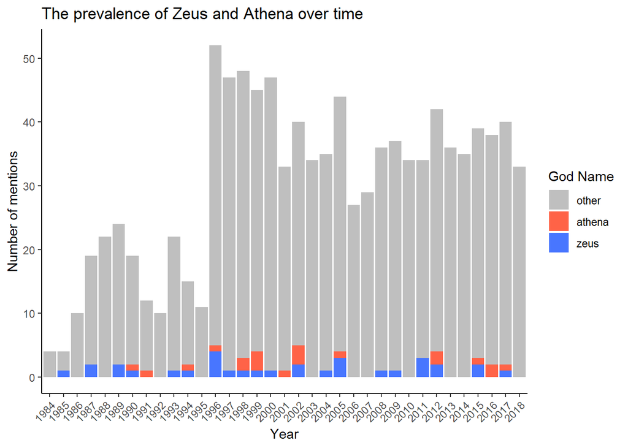

The plot shows that both Zeus and Athena consistently show up in either the answer or question over time, with Athena appearing ~20 times while Zeus appeared ~33 times. While neither appear at all in some years, in others they appear as many as 5 times, with the most popularity within the late 90s and early 2000s.

## Filter the ZA dataframe to top 5 categories and fill by Zeus or Athena

A separate dataframe with just Zeus/Athena (ZA) and the top 5 categories found to be the most prevalent using all 15 gods was created. Releveling/renaming was reperformed the same as above, and graphing of each of these categories with the prevalence of Zeus and Athena was performed.

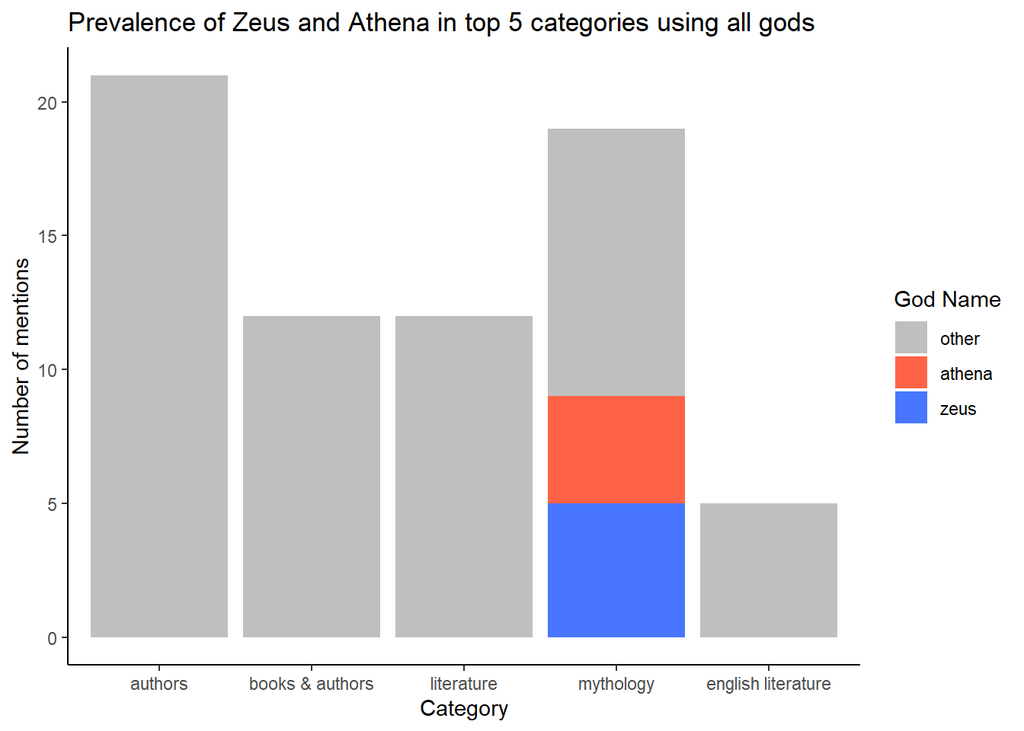

The graph shows that among the top 5 categories, Zeus and Athena appear only in the mythology category. This was surprising to us, as I expected them to appear in some other top categories as well. There are several other miscellaneous categories in which they appear, including “hodgepodge”, “greek mythology”, and “zeus your daddy”, but it seems that Norse gods (data not shown) are who dominate the Authors, Books & Authors, Literature, and English literature categories, with Hindu gods having very little prevalence.